# Tarea III

Heriberto Espino

2024-10-22

Se usan funciones nativas de r y se comparan los resultados con el procedimiento :)

# Ejercicio 1

Un administrador de un hospital sospecha que el retraso en el pago de las facturas hospitalarias ha aumentado de un año a otro. Según los registros del hospital, encontró que durante abril de 2017, 34 de 1001 personas tuvieron un retraso en los pagos de más de 90 días. En abril de 2018, las estadísticas fueron de 49 de 1283. ¿Hay evidencia para pensar que ha habido un aumento en la tasa de morosidad en los pagos que superan los 90 días?

$H_0:p_{2017} > p_{2018}$ vs $H_a:p_{2017} \leq p_{2018}$

**Hipotesis nula:** La tasa de morosidad en 2017 es mayor o igual que en 2018 vs **Hipótesis alternativa:** La tasa de morosidad en 2018 ha aumentado en comparación con 2017).

```r
# Datos
n_2017 <- 1001
n_2018 <- 1283

x_2017 <- 34
x_2018 <- 49

# Proporciones observadas
p_2017 <- x_2017 / n_2017
p_2018 <- x_2018 / n_2018

# Proporción combinada
p_0 <- (x_2017 + x_2018) / (n_2017 + n_2018)

(prop.test(c(x_2017, x_2018), c(n_2017, n_2018), alternative = "less", correct = FALSE))
```

```
    2-sample test for equality of proportions without continuity correction

data:  c(x_2017, x_2018) out of c(n_2017, n_2018)
X-squared = 0.28672, df = 1, p-value = 0.2962
alternative hypothesis: less
95 percent confidence interval:
 -1.000000000  0.008664137
sample estimates:
    prop 1     prop 2
0.03396603 0.03819174
```

```r
z <- (p_2017 - p_2018) / sqrt(p_0 * (1 - p_0) * (1/n_2017 + 1/n_2018))
z
```

```
[1] -0.5354617
```

```r
p_valor <- pnorm(z, lower.tail = TRUE)
p_valor
```

```
[1] 0.2961653
```

# Ejercicio 2

Realiza una prueba con un nivel de significancia del 5% para determinar si la media de los niveles de colesterol en adultos de dicha cuidad supera los 200 mg/dL.

$H_0: \mu \leq 200$ vs $H_a: \mu > 200$

**Hipótesis nula:** La media de los niveles de colesterol en adultos de la ciudad es menor o igual a 200 mg/dL vs **Hipótesis alternativa:** La media de los niveles de colesterol en adultos de la ciudad es mayor a 200 mg/dL.

```r
# Datos
colesterol <- c(210, 190, 205, 220, 195, 225, 200, 215, 210, 180,
                205, 195, 210, 220, 195, 230, 205, 210, 200, 215,
                225, 190, 210, 220, 200, 210, 205, 195, 215, 210)

mu_X <- 200
X_barra <- mean(colesterol)
s <- sd(colesterol)
n <- length(colesterol)

(prueba_t <- t.test(colesterol, mu = mu_X, alternative = "greater"))
```

```
    One Sample t-test

data:  colesterol
t = 3.3489, df = 29, p-value = 0.001131
alternative hypothesis: true mean is greater than 200
95 percent confidence interval:
 203.5306      Inf
sample estimates:
mean of x
 207.1667
```

```r
t_observado <- (X_barra - mu_X) / (s / sqrt(n))
t_observado
```

```
[1] 3.348946
```

```r
p_valor <- pt(t_observado, df = n - 1, lower.tail = FALSE)
p_valor
```

```
[1] 0.001130798
```

# Ejercicio 3

Se seleccionan dos grupos de estudiantes, uno que estudia en la mañana y otro en la tarde, para medir el rendimiento académico. Las puntuaciones de los estudiantes son las siguientes:

Grupo Mañana: 78, 85, 90, 88, 76, 82, 85, 89, 91, 80

Grupo Tarde: 75, 80, 85, 83, 78, 77, 82, 84, 86, 81

El director esta interesado en saber si existe una diferencia significativa de rendimientos entre los estudiantes de la Mañana y los de Tarde. Realice la Prueba de Hipótesis correspondiente.

$H_0: X = Y$ vs $H_a: X \neq Y$

```r
# Datos
grupo_manana <- c(78, 85, 90, 88, 76, 82, 85, 89, 91, 80)
grupo_tarde <- c(75, 80, 85, 83, 78, 77, 82, 84, 86, 81)

(prueba_t <- t.test(grupo_manana, grupo_tarde, alternative = "two.sided", var.equal = FALSE))
```

```
    Welch Two Sample t-test

data:  grupo_manana and grupo_tarde
t = 1.6425, df = 15.971, p-value = 0.12
alternative hypothesis: true difference in means is not equal to 0
95 percent confidence interval:
 -0.9598327  7.5598327
sample estimates:
mean of x mean of y
     84.4      81.1
```

```r
X <- grupo_manana
Y <- grupo_tarde

n_X <- length(X)
n_Y <- length(Y)

X_barra <- mean(X)
Y_barra <- mean(Y)

s2_X <- var(X)
s2_Y <- var(Y)

gamma_X <- s2_X / n_X
gamma_Y <- s2_Y / n_Y

t_observado <- (X_barra - Y_barra) / sqrt(gamma_X + gamma_Y)
t_observado
```

```
[1] 1.642489
```

```r
V_s <- (gamma_X + gamma_Y)^2 / ( (gamma_X^2) / (n_X - 1) + (gamma_Y^2) / (n_Y - 1) )
V_s
```

```
[1] 15.97076
```

```r
p_valor <- 2 * pt(-abs(t_observado), V_s)
p_valor
```

```
[1] 0.120029
```

# Extra 2

Realiza y compara una prueba usando bootstrap para esta prueba. Muestra una gráfica de la distribución bootstrap del estadístico comparada con la distribución teórica (bajo normalidad).

```r
B <- 1000 # Número de muestras bootstrap

diferencia_observada <- mean(X) - mean(Y)   # Diferencia de medias observada

datos_combinados <- c(X, Y)     # Unir los grupos para hacer el remuestreo bajo la hipótesis nula
# Generar una matriz de muestras bootstrap
# Cada columna es una nueva muestra de los datos combinados
muestras_bootstrap <- matrix(sample(datos_combinados, (n_X + n_Y) * B,
                                    replace = TRUE), n_X + n_Y, B)

# Dividir las muestras bootstrap en las correspondientes para X y Y
X_bootstrap <- muestras_bootstrap[1:n_X, ]
Y_bootstrap <- muestras_bootstrap[(n_X + 1):(n_X + n_Y), ]

# Calcular las diferencias de medias de cada muestra bootstrap
diferencias_bootstrap <- colMeans(X_bootstrap) - colMeans(Y_bootstrap)

# Se usa valor absoluto porque es una prueba de dos colas
p_valor_bootstrap <- mean(abs(diferencias_bootstrap) >= abs(diferencia_observada))
p_valor_bootstrap
```

```
[1] 0.113
```

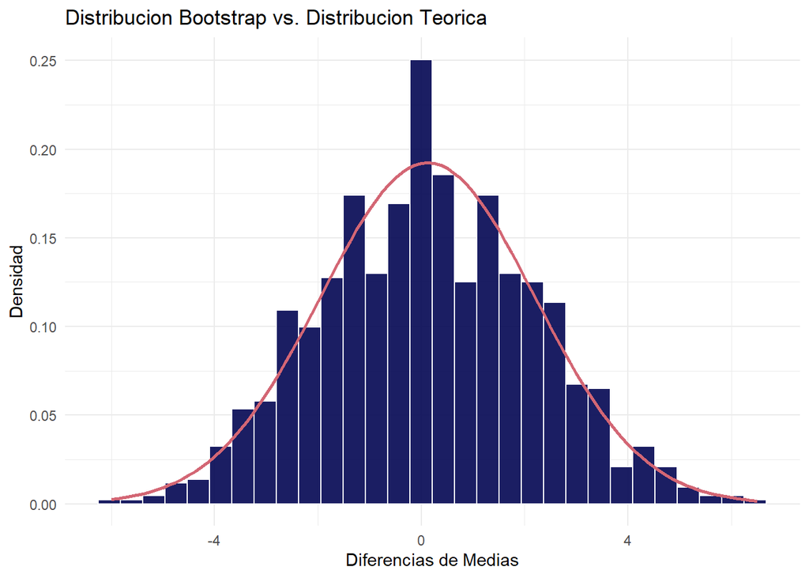

```r
media_bootstrap <- mean(diferencias_bootstrap)
sd_bootstrap <- sd(diferencias_bootstrap)

# Graficar
library(ggplot2)
ggplot(data.frame(diferencias_bootstrap = diferencias_bootstrap), aes(x = diferencias_bootstrap)) +
  geom_histogram(aes(y = ..density..), bins = 30, fill = "#020652", color = "#FFFFFF", alpha = 0.9) +
  stat_function(fun = dnorm, args = list(mean = media_bootstrap, sd = sd_bootstrap), color = "#D36674", size = 1) +
  labs(title = "Distribucion Bootstrap vs. Distribucion Teorica",
       x = "Diferencias de Medias",
       y = "Densidad") +
  theme_minimal()
```

# Ejercicio 4

Un fabricante de bombillas afirma que el 95 % de sus productos duran más de 1000 horas. Para verificar esta afirmación, se selecciona una muestra de 200 bombillas y se encuentra que 185 duran más de 1000 horas. Realice una prueba para ver si el fabricante miente, obtenga el p-valor exacto y compárelo con la aproximación usando el TLC con y sin corrección de continuidad

$H_0: \hat{p_0} \geq 0.95$ vs $H_a: \hat{p_0} \leq 0.95$

```r
# Datos
n <- 200
X <- 185
p_0 <- 0.95
p_muestral <- X / n
p_muestral - p_0
```

```
[1] -0.025
```

```r
# ------------------------------ p-valor exacto ------------------------------
p_valor_real <- pbinom(X, n, p_0, lower.tail = TRUE)
p_valor_real
```

```
[1] 0.07813442
```

```r
# ---------------------- Sin corrección de continuidad ----------------------
p_valor_TLC <- 1 - pnorm(1.62, lower.tail = TRUE)
p_valor_TLC
```

```
[1] 0.05261614
```

```r
# ---------------------- Con corrección de continuidad  ----------------------
p_valor_correcion <- 1 - pnorm(1.45, lower.tail = TRUE)
p_valor_correcion
```

```
[1] 0.07352926
```

# Ejercicio 5

Busque determinar si el programa de ejercicio tiene un efecto significativo en la reducción del peso. Además realice alguna validación visual para corroborar el supuesto de normalidad que esta detrás de la prueba, si este no se cumple, haga y compare el resultado de una prueba bootstrap.

$H_0: X = Y$ vs $H_a: X \neq Y$

```r
# Datos
antes <- c(88, 72, 82, 64, 72, 110, 79, 106, 72, 63, 59, 109,
           62, 97, 78, 92, 88, 79, 60, 65, 78, 70, 66, 66, 121)
despues <- c(83, 71, 74, 62, 88, 81, 81, 98, 64, 61, 59, 80, 68,
             75, 96, 81, 81, 60, 57, 63, 71, 69, 68, 69, 73)


(t.test(antes, despues, paired = TRUE, alternative = "two.sided"))
```

```
    Paired t-test

data:  antes and despues
t = 2.3252, df = 24, p-value = 0.02884
alternative hypothesis: true mean difference is not equal to 0
95 percent confidence interval:
  0.741775 12.458225
sample estimates:
mean difference
            6.6
```

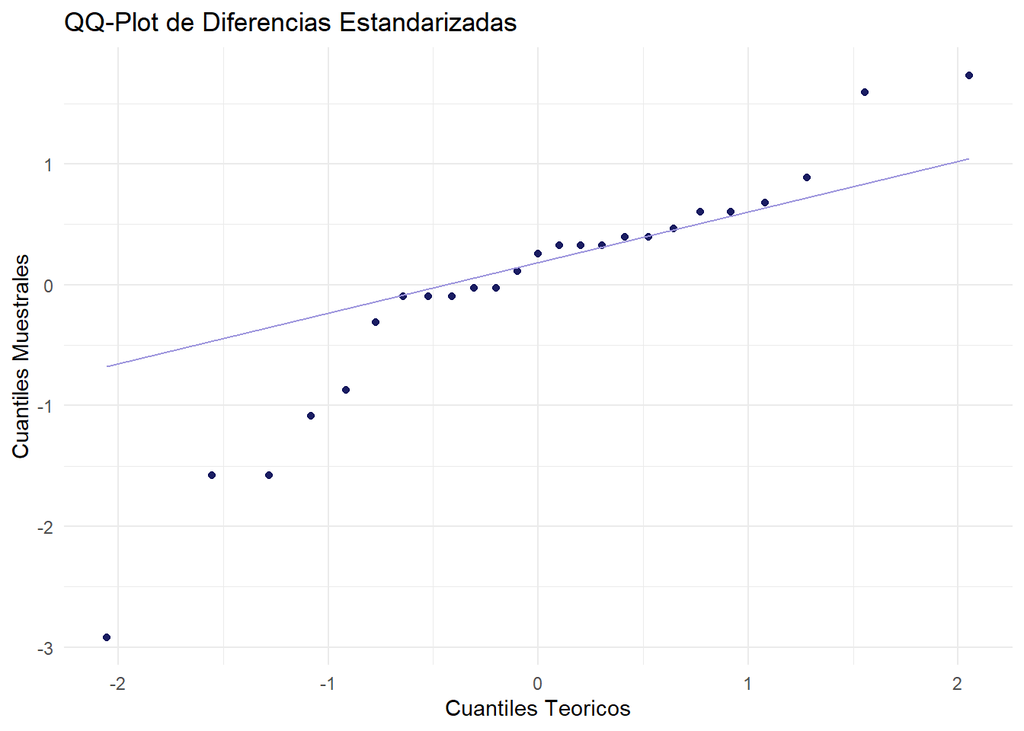

```r
diferencias <- despues - antes

n <- length(diferencias)
X_barra <- mean(diferencias)
s <- sd(diferencias)

# QQ plot
diferencias_std <- (diferencias - X_barra) / s

# Crear un qq plot
library(ggplot2)
ggplot(data.frame(diferencias_std), aes(sample = diferencias_std)) +
  stat_qq(color = "#020652", alpha = 0.9) +
  stat_qq_line(color = "#9D95DD") +
  labs(title = "QQ-Plot de Diferencias Estandarizadas",
       x = "Cuantiles Teoricos",
       y = "Cuantiles Muestrales") +
  theme_minimal()
```

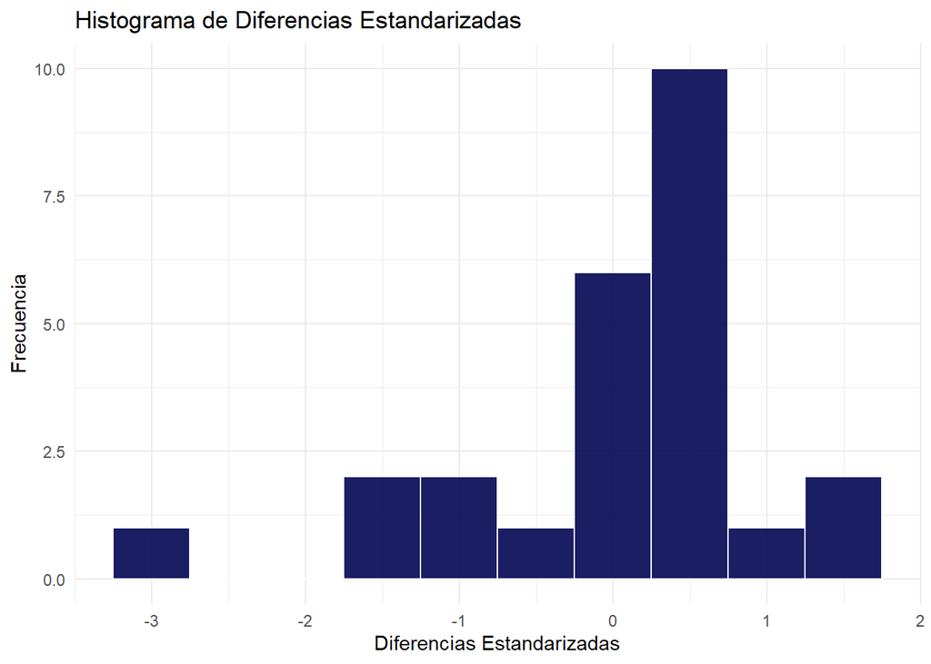

```r
# Crear un histograma con ggplot2
ggplot(data.frame(diferencias_std), aes(x = diferencias_std)) +
  geom_histogram(binwidth = 0.5, fill = "#020652", color = "#FFFFFF", alpha = 0.9) +
  labs(title = "Histograma de Diferencias Estandarizadas",
       x = "Diferencias Estandarizadas",
       y = "Frecuencia") +
  theme_minimal()
```

```r
t_observado <- X_barra / (s / sqrt(n))
t_observado
```

```
[1] -2.325232
```

```r
# p-valor
p_valor <- 2 * pt(-abs(t_observado), df = n - 1)
p_valor
```

```
[1] 0.02883791
```

```r
# ---------------- Bootstrap  ----------------
B <- 10000

# Generamos una matriz de muestras bootstrap
muestras_bootstrap <- matrix(sample(diferencias, n * B, replace = TRUE), n, B)

# Calculamos las medias de cada muestra bootstrap
medias_bootstrap <- colMeans(muestras_bootstrap)

# Calculamos las varianzas de cada muestra bootstrap
varianzas_bootstrap <- apply(muestras_bootstrap, 2, var)

# Calculamos los estadísticos t de bootstrap
t_bootstrap <- (medias_bootstrap - X_barra) / (sqrt(varianzas_bootstrap) / sqrt(n))

# Calculamos el p-valor usando el método bootstrap
p_valor_bootstrap <- mean(abs(t_bootstrap) >= abs(t_observado))
p_valor_bootstrap
```

```
[1] 0.0393
```